# Integración de Shodan y CPE-CVE

## Objetivo del package

> El objetivo de esta práctica es realizar una consulta a [Shodan](https://www.shodan.io/) sobre equipos que utilicen **Apache** como publicador web o de aplicaciones. Una vez obtenido este dato, se cruza la información con **Nist**, para obtener las potenciales vulnerabilidades que tendrían las plataformas consultadas a través del buscador.

## Funciones usadas en el package

#### `DescargarFicheros()`

> La función *DescargarFicheros* verifica que exista la ruta donde vamos a guardar el fichero con los datos y posteriormente realiza la descarga y descompresión del mismo.  
> Ejemplo de uso:

```
DescargarFicheros()
```

#### `ConsultarShodan()`

> La función *ConsultarShodan* realiza una consulta a [Shodan](https://www.shodan.io/) mediante el uso de API. La consulta llevada a cabo en esta práctica es **apache**. Tratamos de buscar los servidores apacha publicados a en internet y que no ocultan el Header Server.  
> Ejemplo de uso:

```
ConsultarShodan(query)
```

#### `ParserShodan()`

> La función *ParserShodan* realiza un parseo de los datos descargados de la consulta a [Shodan](https://www.shodan.io/). Se crea un data frame y luego se eliminan los duplicados devueltos por la consulta.  
> Ejemplo de uso:

```
ParserShodan()
```

#### `ParserNVD()`

> La función *ParserNVD* realiza un parseo del documento del *NIST*. Mediante consultas *XPATH* obtenemos los valores necesarios (CVE-CPE) para conseguir el data frame.  
> Ejemplo de uso:

```
ParserNVD()
```

#### `UnirDatos(df1, df2)`

> La función *UnirDatos* une los datos de los data frames creados por *ParserShodan* y *ParserNVD*. La relación entre uno y otro es *CPE.product*. Como resultado obtenemos un tercer data frame con los datos listos para explotar.  
> Ejemplo de uso:

```
UnirDatos(df1, df2)
```

#### `ContarTotalCVE_CPE(df)`

> La función *ContarTotalCVE_CPE* realiza un conteo del data frame resultante de la función *UnirDatos*. El conteo se lleva a cabo mediente el campo *CPE.product*.  
> Ejemplo de uso:

```
ContarTotalCVE_CPE(df)
```

#### `ContarTotalCVEs(df)`

> La función *ContarTotalCVEs* realiza un conteo del data frame resultante de la función *UnirDatos*. El conteo se lleva a cabo mediente el campo *CPE.product*.  
> Ejemplo de uso:

```
ContarTotalCVEs(df)
```

## Gráficas obtenidas mediante el estudio

#### Agrupación de CPE’s por CVSS (Score) de CVE

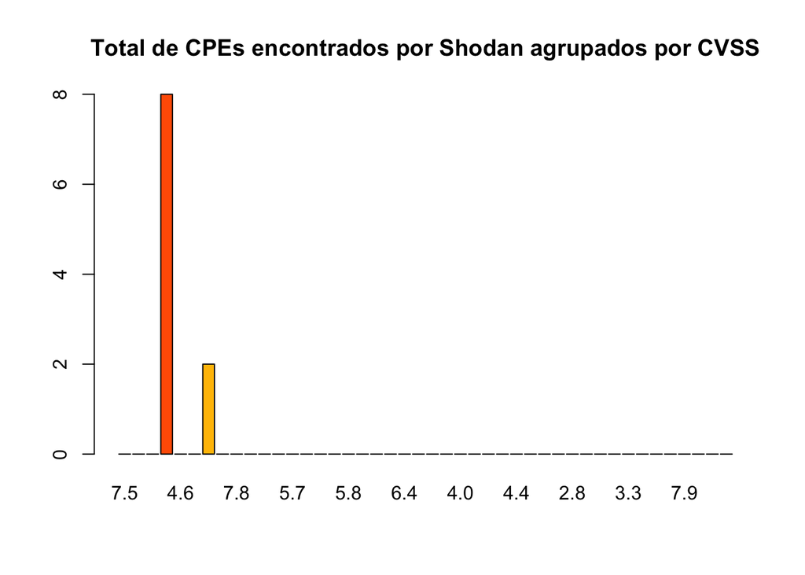

#### Total de CPEs por CVSS (Score)

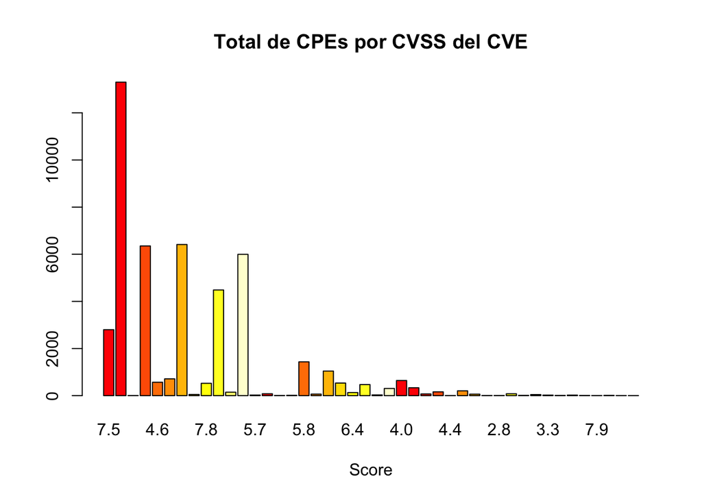

#### Las siguientes gráficas nos muestran el total de CVEs por CVSS y el total de CVEs por año

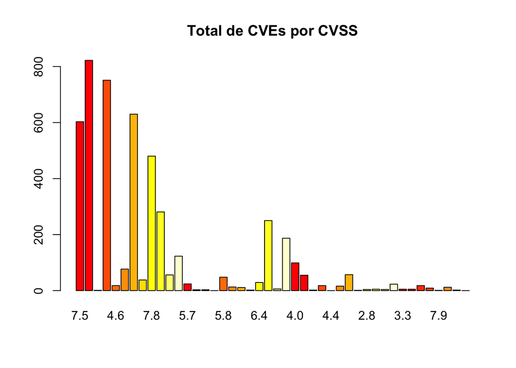

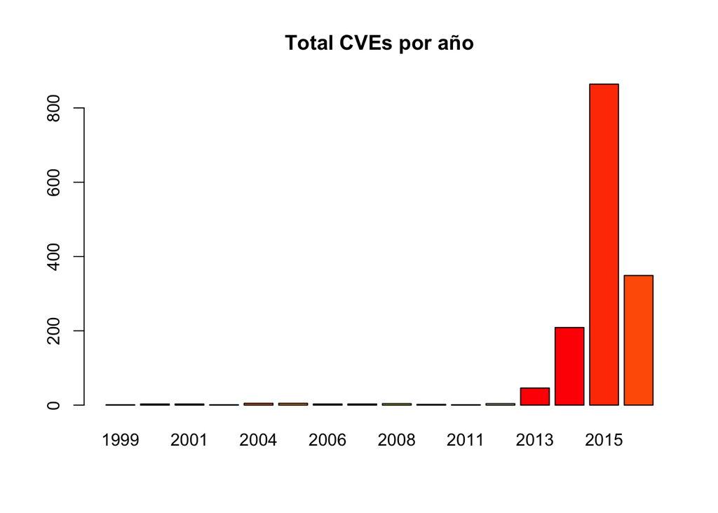

#### Mediante las IP’s y la base de datos se puede geolocalizar las IP y dibujar en plano

[interactive chart not shown]